# ISLR Chapter 7 Exercises

Ryan Heslin

12/2/2020

# Labs

## Non-Linear Modeling

### Polynomial Models

We start with a simple polynomial model. Note that poly() returns columns forming the basis of orthogonal polynomials. Setting raw = TRUE gives the raw polynomials, though this has no effect on the fit.

```r
library(ISLR)
library(tidyverse)
library(rlang)
wage <- Wage

fit1 <- lm(wage ~poly(age, 4), data = wage)
summary(fit1)
```

```
##
## Call:
## lm(formula = wage ~ poly(age, 4), data = wage)
##
## Residuals:
##     Min      1Q  Median      3Q     Max
## -98.707 -24.626  -4.993  15.217 203.693
##
## Coefficients:
##                Estimate Std. Error t value Pr(>|t|)
## (Intercept)    111.7036     0.7287 153.283  < 2e-16 ***
## poly(age, 4)1  447.0679    39.9148  11.201  < 2e-16 ***
## poly(age, 4)2 -478.3158    39.9148 -11.983  < 2e-16 ***
## poly(age, 4)3  125.5217    39.9148   3.145  0.00168 **
## poly(age, 4)4  -77.9112    39.9148  -1.952  0.05104 .
## ---
## Signif. codes:  0 '***' 0.001 '**' 0.01 '*' 0.05 '.' 0.1 ' ' 1
##
## Residual standard error: 39.91 on 2995 degrees of freedom
## Multiple R-squared:  0.08626,    Adjusted R-squared:  0.08504
## F-statistic: 70.69 on 4 and 2995 DF,  p-value: < 2.2e-16
```

```r
coef(summary(fit1))
```

```
##                 Estimate Std. Error    t value     Pr(>|t|)
## (Intercept)    111.70361  0.7287409 153.283015 0.000000e+00
## poly(age, 4)1  447.06785 39.9147851  11.200558 1.484604e-28
## poly(age, 4)2 -478.31581 39.9147851 -11.983424 2.355831e-32
## poly(age, 4)3  125.52169 39.9147851   3.144742 1.678622e-03
## poly(age, 4)4  -77.91118 39.9147851  -1.951938 5.103865e-02
```

```r
fit2 <- lm(wage ~poly(age, 4, raw = TRUE),data = wage)
coef(summary(fit2))
```

```
##                                Estimate   Std. Error   t value     Pr(>|t|)
## (Intercept)               -1.841542e+02 6.004038e+01 -3.067172 0.0021802539
## poly(age, 4, raw = TRUE)1  2.124552e+01 5.886748e+00  3.609042 0.0003123618
## poly(age, 4, raw = TRUE)2 -5.638593e-01 2.061083e-01 -2.735743 0.0062606446
## poly(age, 4, raw = TRUE)3  6.810688e-03 3.065931e-03  2.221409 0.0263977518
## poly(age, 4, raw = TRUE)4 -3.203830e-05 1.641359e-05 -1.951938 0.0510386498
```

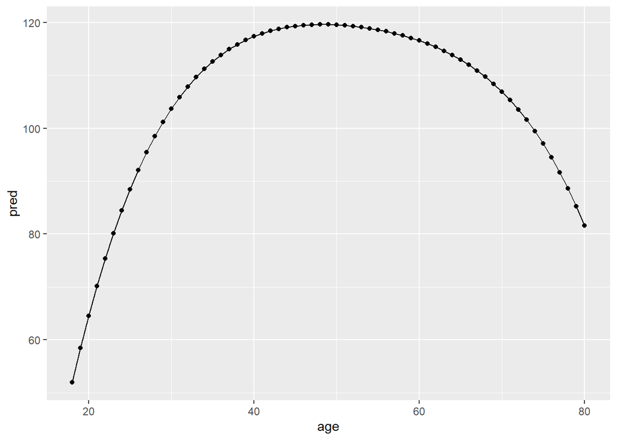

```r
grid <- seq(min(wage$age), max(wage$age))
pred <- predict(fit1, newdata = list(age = grid), se = TRUE)

tibble(age = grid, pred = pred$fit ) %>%
  ggplot(aes(x = age, y = pred)) +
  geom_line()+
  geom_point()
```

```r
library(rlang)
forms <- list(expr(lm(wage ~ age, data = wage)), substitute(wage ~poly(age,x), list(x = 2:5)))

forms <- list(expr(lm(wage ~ age, data = wage)), NA, NA, NA, NA)


fit_polys <- function(resp, pred, dat, n){
  resp <- ensym(resp)
  pred = ensym(pred)
  dat <- ensym(dat)
  poly_call <- expr(poly(!!resp, degree = !!n))
  form <- expr(!!resp ~ !!poly_call)
  lm_call <- call2(quote(lm), !!!list(formula = form, data = dat) )

  lm_call
}


forms <- map(3:5, ~fit_polys(wage, age, wage, .x))

fits <- map(forms, eval)
do.call(anova, fits)
```

```
## Analysis of Variance Table
##
## Model 1: wage ~ poly(wage, degree = 3L)
## Model 2: wage ~ poly(wage, degree = 4L)
## Model 3: wage ~ poly(wage, degree = 5L)
##   Res.Df        RSS Df  Sum of Sq      F Pr(>F)
## 1   2996 8.7579e-22
## 2   2995 8.7579e-22  1 1.2510e-28 0.0004 0.9835
## 3   2994 8.7577e-22  1 1.8995e-26 0.0649 0.7989
```

### Binomial Models

Nice trick with the conditional response. The predictions are remarkably good

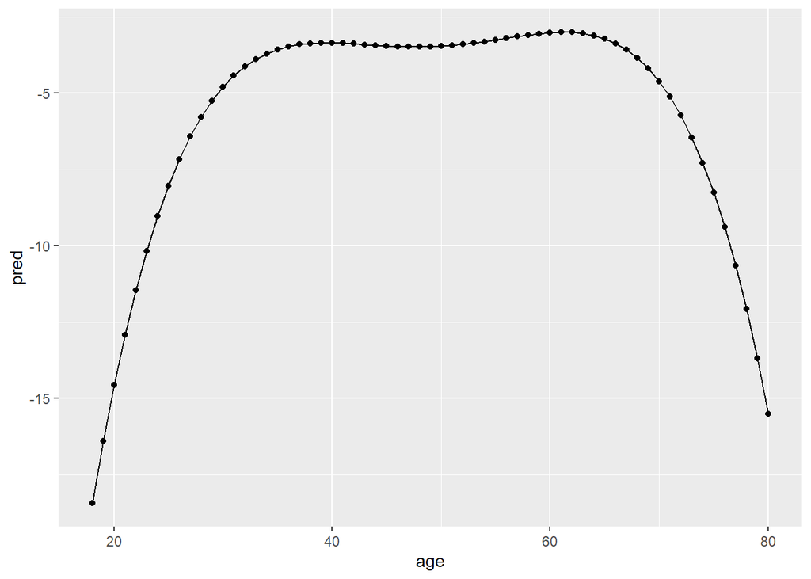

```r
fit3=glm(I(wage>250) ∼poly(age,4),data=Wage, family=binomial)
preds <- predict(fit3, newdata = list(age = grid), se = TRUE)
p1 <- tibble(age = grid, pred = preds$fit) %>%
  ggplot(aes(x = age, y = pred)) +
  geom_line()+
  geom_point()
p1
```

By default, this gives predictions in the form $X\hat\beta$ - the log odds (log of probability divided by complement). Recall the beta in logit regression represents the effect on X required to get the power to which $e$ must be raised to equal the odds. We raise to the $e$th power to get:
$$Pr(Y=1|X)= \frac{\exp{X\beta}}{1 + \exp{X\beta}}$$

So: COnfidence intervals have to be computed manually this way, since by default the function gives negative CIs for probabilities

```r
prob <- exp(preds$fit)/(1+preds$fit)
se_probs <- tibble(lower = preds$fit + 2*preds$se.fit, upper = preds$fit - 2*preds$se.fit) %>%
  apply(MARGIN = 2, function(x) exp(x) /(1 +exp(x))) %>%
  as_tibble()

#cool se band plot in progress
# p1 +
# geom_point(data = se_probs, aes(x = lower, y = upper)) +
#   geom_line(col = "blue")
```

### Stepwise Polynomials

Cut is useful here. Note the first interval is omitted and used as the intercept.

```r
fit4 <- lm(wage~cut(age, 4), data = Wage)
```

## Splines

We need the spline library to fit splines. splines::bs() generates basis functions for splines with the given knots (cubic by default).

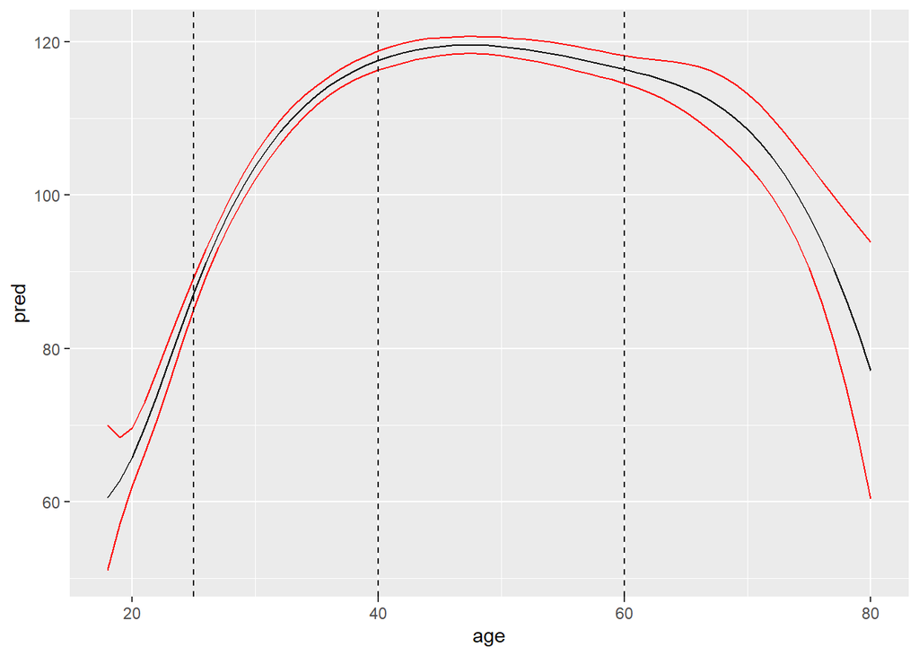

```r
library(splines)
fit5 <- lm(wage~bs(age, knots = c(25, 40, 60)), data = wage)
pred <- predict(fit5, newdata = list(age = grid), se = TRUE)

data.frame(pred = pred$fit, age = grid, se = pred$se.fit) %>%
  ggplot(aes(x = age, y = pred)) +
  geom_line()+
  geom_line(aes(y = pred + se), col = "red")+
geom_line(aes(y = pred - se), col = "red") +
  geom_vline(xintercept = c(25,40,60), linetype = "dashed")
```

We could also use the df arg to fit a certain number of basis functions (a 3-knot cubic has 7 df, for instance).

Use ns to fit natural splines. Here are two possible approaches: choose lambda with target df, or by optimizing with cross-validation. Loess is used for local regression

```r
fit6=lm(wage∼ns(age,df=4),data=Wage)
pred2=predict(fit2,newdata=list(age=grid),se=T)

fit7 <- smooth.spline(wage$age, wage$wage, cv = TRUE)
fit8 <- smooth.spline(wage$age, wage$wage, df =16)
```

## GAMs

Just fit a standard lm, with each predictor transformed as desired.

```r
gam1=lm(wage∼ns(year,4)+ns(age,5)+education, data=Wage)
```

To use smoothing splines or other methods that can’t be reduced to basis functions, we need the GAM library. Here we create two smoothing splines and add a factor variable (converted to dummies) for fun.

```r
library(gam)
```

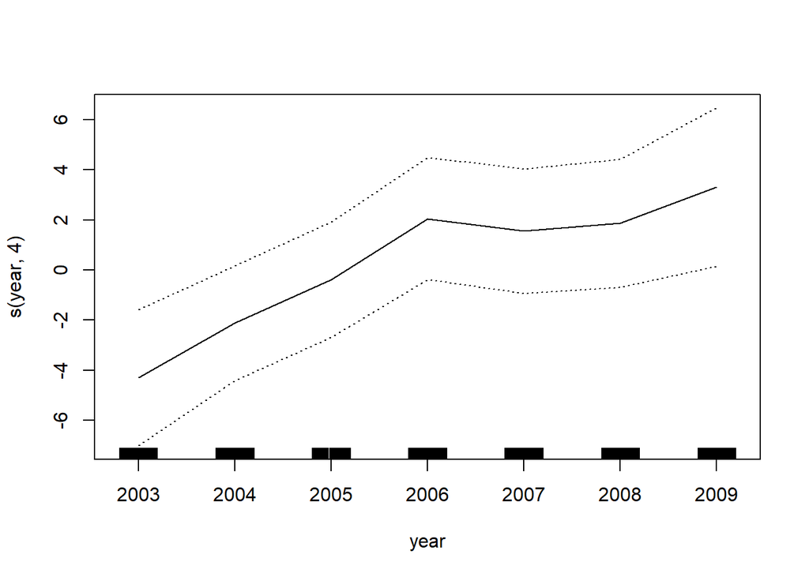

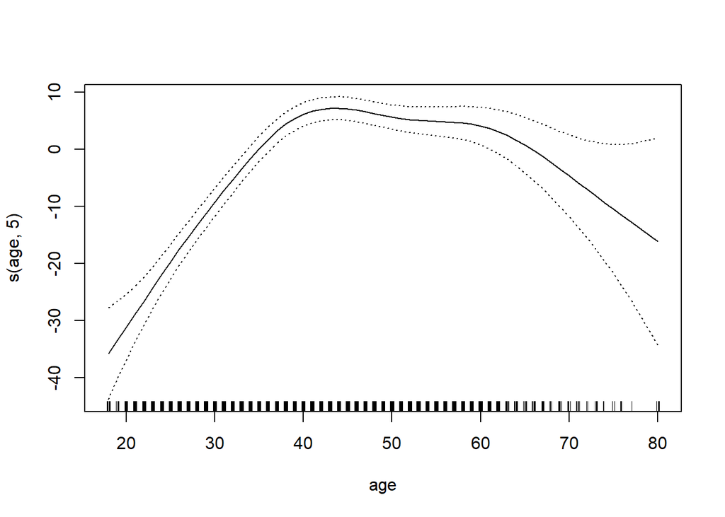

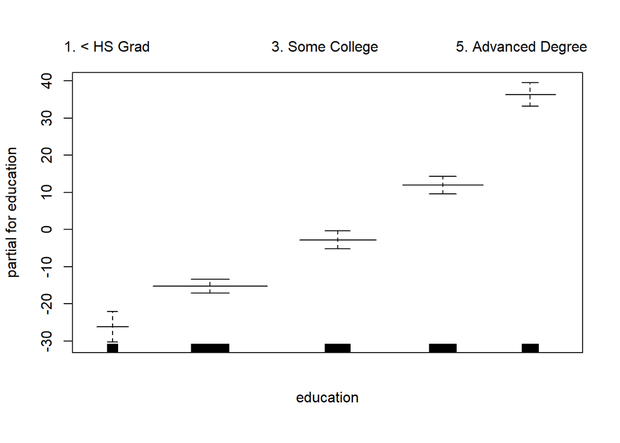

```r
gam2 <- gam(wage~(s(year, 4) + s(age, 5) +education), data = wage)
plot(gam2, se = TRUE)
```

The fit for year looks pretty linear. We should run an ANOVA to determine whether year should be omitted, treated as is, or fit to a smoothing splines. The last significant value is for the linear year model, so that one is best. The summary for the linear year model SHOULD have a high p-value for the F-test for year, indicating a likely linear relationship, but does not.

```r
gam.m1 <- gam(wage∼(s(age,5)+education),data=wage)
gam.m2 <- gam(wage∼(year+s(age,5)+education),data=wage)
anova(gam.m1, gam.m2, gam2, test="F")
```

```
## Analysis of Deviance Table
##
## Model 1: wage ~ (s(age, 5) + education)
## Model 2: wage ~ (year + s(age, 5) + education)
## Model 3: wage ~ (s(year, 4) + s(age, 5) + education)
##   Resid. Df Resid. Dev Df Deviance       F    Pr(>F)
## 1      2990    3711731
## 2      2989    3693842  1  17889.2 14.4771 0.0001447 ***
## 3      2986    3689770  3   4071.1  1.0982 0.3485661
## ---
## Signif. codes:  0 '***' 0.001 '**' 0.01 '*' 0.05 '.' 0.1 ' ' 1
```

```r
summary(gam.m2)
```

```
##
## Call: gam(formula = wage ~ (year + s(age, 5) + education), data = wage)
## Deviance Residuals:
##      Min       1Q   Median       3Q      Max
## -119.959  -19.647   -3.199   13.969  213.562
##
## (Dispersion Parameter for gaussian family taken to be 1235.812)
##
##     Null Deviance: 5222086 on 2999 degrees of freedom
## Residual Deviance: 3693842 on 2989 degrees of freedom
## AIC: 29885.06
##
## Number of Local Scoring Iterations: NA
##
## Anova for Parametric Effects
##             Df  Sum Sq Mean Sq F value    Pr(>F)
## year         1   27154   27154  21.973  2.89e-06 ***
## s(age, 5)    1  194535  194535 157.415 < 2.2e-16 ***
## education    4 1069081  267270 216.271 < 2.2e-16 ***
## Residuals 2989 3693842    1236
## ---
## Signif. codes:  0 '***' 0.001 '**' 0.01 '*' 0.05 '.' 0.1 ' ' 1
##
## Anova for Nonparametric Effects
##             Npar Df Npar F     Pr(F)
## (Intercept)
## year
## s(age, 5)         4  32.46 < 2.2e-16 ***
## education
## ---
## Signif. codes:  0 '***' 0.001 '**' 0.01 '*' 0.05 '.' 0.1 ' ' 1
```

Use the lo function to fit local regressions as elements of a GMA. lo can also fit local regressions on interactions (a 2d surface).

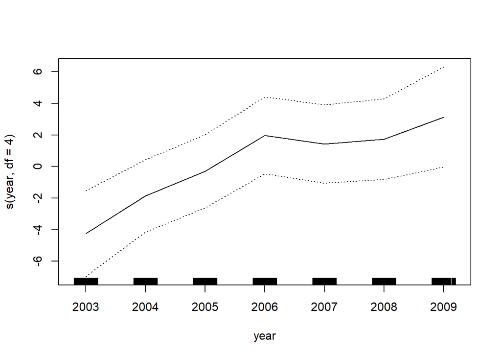

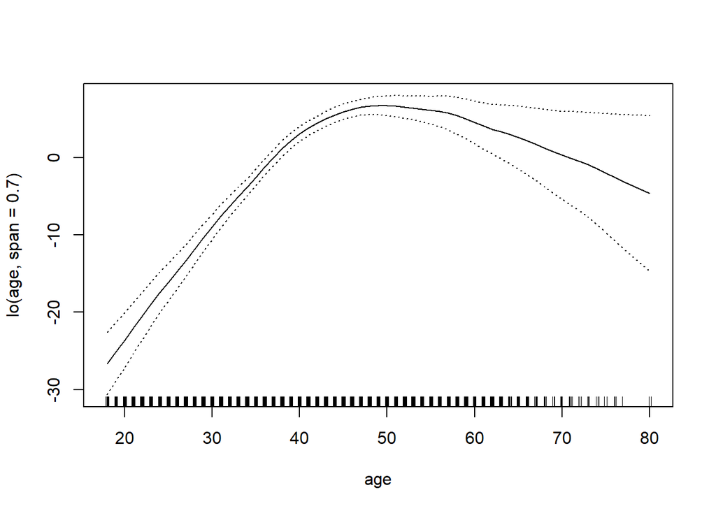

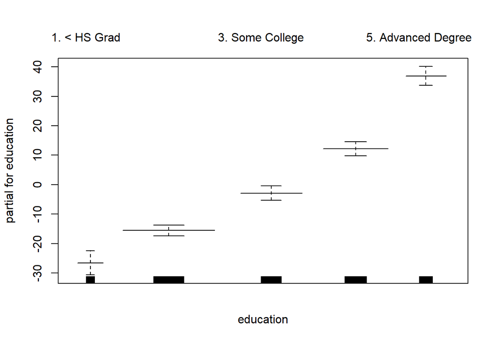

```r
preds <- predict(gam.m2, newdata = wage)
gam3 <- gam(wage ~(s(year, df = 4)+lo(age, span = .7)+education), data = wage)
plot(gam3, se = TRUE)
```

```r
gam4 <- gam(wage∼(lo(year,age,span=0.5)+education),data=Wage)
```

Use family = binomial to fit a logistic GAM. Here we would need to drop the < high school education category because it has no cases in the response variable (wage > 250).

# Exercises

## 2.

We are asked to estimate the shape of natural splines fitted using various values of $\lambda$ for one of $m$ derivatives.

(b)λ=∞,m=1.(c)λ=∞,m=2.(d)λ=∞,m=3.(e)λ=0,m=3 λ=∞,m=0.

I initially had this wrong - if $\lambda=\infty$, then the RSS term becomes irrelevant and we care only about minimizing the integral term. In that case, $g(x)$ has to have degree one greater than $m$ to minimize the area under the curve. If $\lambda = 0$, then we only care about the RSS term, so we just use the OLS estimate.

## 3.

We are asked to consider a set of basis functions. Suppose we fit a curve with basis functions1(X)=X,b2(X)=(X−1)2I(X≥1). (Note that(X≥1) equals 1 forX≥1and0otherwise.) We fit the linear regression modelY=β0+β1b1(X)+β2b2(X)+,and obtain coefficient estimatesˆβ0=1,ˆβ1=1,ˆβ2=−2. Sketch theestimated curve betweenX=−2andX= 2. Note the intercepts,slopes, and other relevant information.

This fit squares only those values of $X$ above or equal to 1, so $b2(X) >= b1(X)$. Let’s plot the curve and cheat:

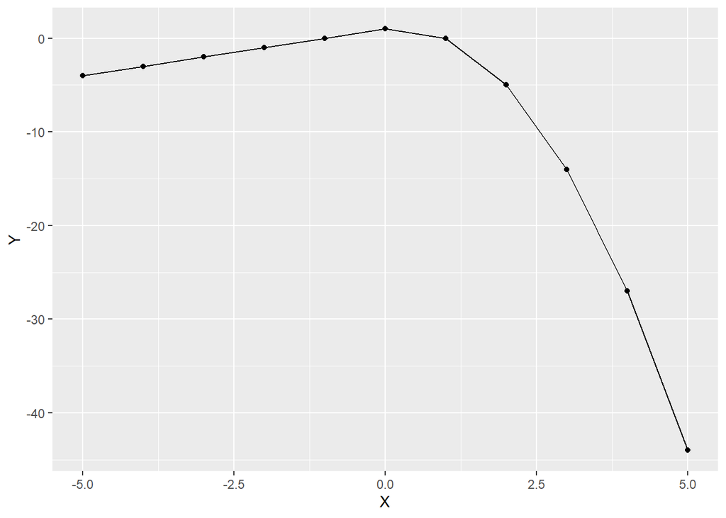

```r
X <- -5:5
Y <- 1 + X*1  - ifelse(X >=1, X^2, 0)*2

tibble(X = X, Y = Y) %>%
  ggplot(aes(x = X, y = Y)) +
  geom_point()+
  geom_line()
```

## 4. Suppose we fit a curve with basis functionsb1(X)=I(0≤X≤2)−(X−1)I(1≤X≤2),b2(X)=(X−3)I(3≤X≤4)+I(4<X≤5).We fit the linear regression modelY=β0+β1b1(X)+β2b2(X),and obtain coefficient estimatesˆβ0=1,ˆβ1=1,ˆβ2=3.

Another one. If I’m reading this right, the first term converts $X$ between 0 and 1 to 1, multiplies $X$ ebtween 1 and 2 by -1, and converts all others to 0. The second reduces $X$ between 3 and 4 by 3, then converts $X$ between 4 and 5 to , zeroing out all others. I expect to see a lfat line at 1 between 0 and 1, a line with slope -1 from 1 to 2, a line with slope 3 from 3 to 4, then another flat line at 1 Let’s try plotting this mess:

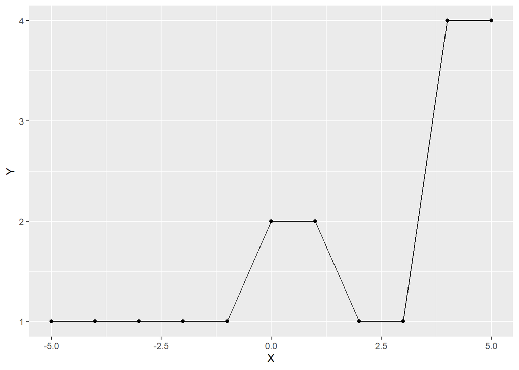

```r
X <- -5:5
Y <- 1 + 1* (ifelse(between(X, 0, 2), 1, 0) -
  (X-1)*ifelse(between(X,  1, 2), 1, 0)) +
  3 * ((X-3) * ifelse(between(X, 3, 4), 1, 0) +ifelse(X > 4 & X <=5, 1, 0))

tibble(X =X, Y = Y) %>%
  ggplot(aes(x = X, y = Y))+
  geom_point() +
  geom_line()
```

I just forgot the beta coefficient for the last interval of the second basis.

##5. We are asked two compare two smothers, one using the third derivative and the otter the fourth. (a) Asλ→∞, will ˆg1or ˆg2have the smaller training RSS?(b) Asλ→∞, will ˆg1or ˆg2have the smaller test RSS?(c) Forλ= 0, will ˆg1or ˆg2have the smaller training and test RSS?

You have this backwards - the higher-order derivatives are MORE flexible because $g$ necessarily has higher degree and therefore more flexibility (an extra df). a. $\hat{g}_2$ has smaller train RSS because it is a higher-order polynomial and is therefore more flexible

2. $\hat{g_1}$, because it is less vulnerable to overfitting.
3. If $\lambda = 0$, neither, because the integral constraint is zeroed out, leaving just the RSS term.

a-d. If lambda is $\infty$, then the fit is just the OLS line no matter the choice of derivative. e. If $\lambda = 0$, the penalty has no effect, so $g(x)$ perfectly interpolates the data.

6. In this exercise, you will further analyze the Wagedata set consideredthroughout this chapter.(a) Perform polynomial regression to predictwageusingage.Usecross-validation to select the optimal degreedfor the polyno-mial. What degree was chosen, and how does this compare tothe results of hypothesis testing using ANOVA? Make a plot ofthe resulting polynomial fit to the data.(b) Fit a step function to predictwageusingage, and perform cross-validation to choose the optimal number of cuts. Make a plot ofthe fit obtained.

We are asked to find optimal polynomial and stepwise fits on wage. I shameless recycle my code to use the ANOVA approach, then use cross-validation.

Bquote is so cool.

```r
library(ISLR)

forms <- list(expr(wage ~ age), NA, NA, NA, NA)
exp <- expr(wage ~ poly(age, i))
for(i in 2:7){

  #exp <- expr(wage~poly(age, i))
  #forms[[i]] <- eval(exp, e)
  forms[[i]] <- bquote(.(bquote(wage~poly(age, .(i)))))
  #forms[[i]] <- expr(!!exp)
}


fits <- map(forms, ~lm(data = wage, formula = .x))
do.call(anova, fits)
```

```
## Analysis of Variance Table
##
## Model 1: wage ~ age
## Model 2: wage ~ poly(age, 2L)
## Model 3: wage ~ poly(age, 3L)
## Model 4: wage ~ poly(age, 4L)
## Model 5: wage ~ poly(age, 5L)
## Model 6: wage ~ poly(age, 6L)
## Model 7: wage ~ poly(age, 7L)
##   Res.Df     RSS Df Sum of Sq        F    Pr(>F)
## 1   2998 5022216
## 2   2997 4793430  1    228786 143.6926 < 2.2e-16 ***
## 3   2996 4777674  1     15756   9.8956  0.001673 **
## 4   2995 4771604  1      6070   3.8125  0.050966 .
## 5   2994 4770322  1      1283   0.8055  0.369516
## 6   2993 4766389  1      3932   2.4697  0.116165
## 7   2992 4763834  1      2555   1.6049  0.205311
## ---
## Signif. codes:  0 '***' 0.001 '**' 0.01 '*' 0.05 '.' 0.1 ' ' 1
```

I write some quasiquoting functions to test MSE because I can. Anyway, we see MSE stops declining meaningfully at degree 4, consistent with the ANOVA.

```r
make_folds <- function(df, k = 10){

  if( nrow(df) %/% k < 2){
    stop("Are you trying to do LOOCV?")
  }

  #randomize rows
  df <- slice_sample(df, n = nrow(df), replace = FALSE)
  over <- nrow(df) %% k
  per_fold <- (nrow(df) - over) /k

  #Get fold cutoffs, 0 as placeholder
  steps <- rep(per_fold, times = k)
  steps[seq_len(over)] <- steps[seq_len(over)] + 1
  splits <- c(0, cumsum(steps))

  #Get index range, sample rows
  inds <- vector("list", length = k)
  inds <- imap(inds, ~`<-`(.x, c(splits[.y] +1, splits[.y +1])))

  out <- map(inds, function(inds){
    samp <- seq(inds[1], inds[2])
    list(train = df[-samp,],
         test = df[samp,])
  }) %>%
    rlang::set_names(nm = as.character(seq_len(k)))

  print(paste("Generated", k, "folds, including", over, "of length", k+1))
  out
}

# I shamelessly abuse quasiquotation here for practice.
cross_valid <- function(form, folds){

  resp <- sym(all.vars(form)[1])
  out <- map_dbl(folds, function(fold){
    fit <- eval(expr(lm(!!form, data)), envir = env(data = fold$train))
    #fit <- exec(lm, form, data = fold$train)
    preds <- predict(fit, newdata = fold$test)
    out <- mean((preds - eval(expr(`$`(fold$test, !!resp))))^2) * #get MSE
      (nrow(fold$test)/ (nrow(fold$test) + nrow(fold$train)))
  })
  out <- sum(out)
  out
}
folds <- make_folds(wage, k = 10)
```

```
## [1] "Generated 10 folds, including 0 of length 11"
```

```r
map(forms, cross_valid, folds = folds)
```

```
## [[1]]
## [1] 1675.979
##
## [[2]]
## [1] 1599.57
##
## [[3]]
## [1] 1595.079
##
## [[4]]
## [1] 1594.183
##
## [[5]]
## [1] 1594.683
##
## [[6]]
## [1] 1593.79
##
## [[7]]
## [1] 1594.069
```

Next we try a stepwise model. It seems that prime working age is 40-60, so I try cutting that range. 8 cuts optimizes MSE, but my experimental model does poorly

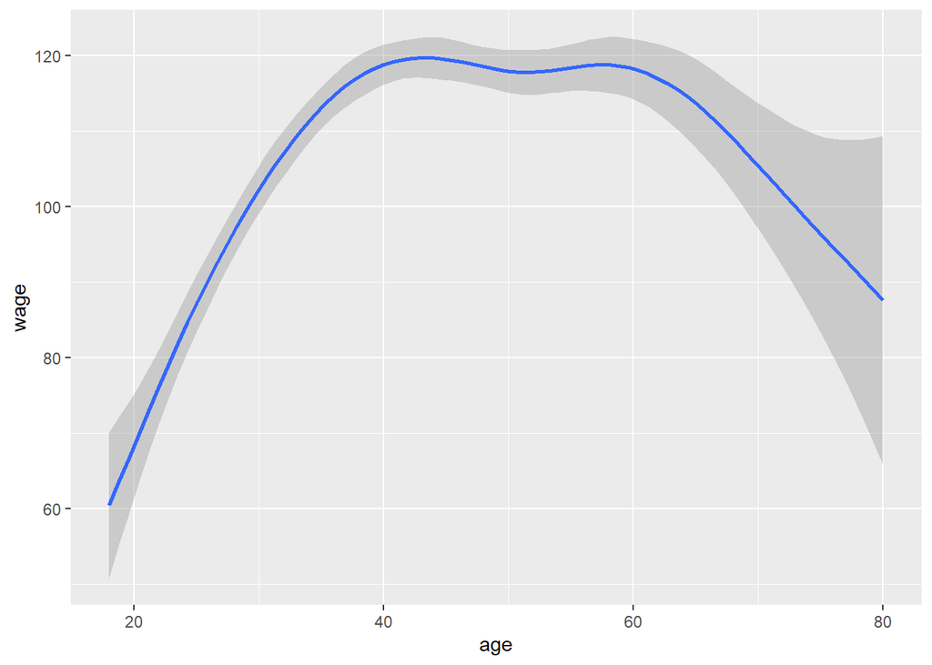

```r
wage %>%
  ggplot(aes(x = age, y = wage)) +
  geom_smooth()
```

```r
mod1 <- lm(wage~cut(age, 4), data = Wage)
mod2 <- lm(wage~cut(age, 5), data = Wage)
mod3 <- wage %>% mutate(age2 = cut(age, breaks = c(min(age), 40, 60, max(age)))) %>%
  lm(data = ., formula = wage ~ age2)

forms <- vector("list")
for(i in 2:10){

  #exp <- expr(wage~poly(age, i))
  #forms[[i]] <- eval(exp, e)
  forms[[i-1]] <- expr(lm(wage ~ cut(age, !!i), data = wage))


}
broom::augment(mod3) %>%
  {mean((.$wage - .$.fitted)^2)}
```

```
## [1] 1691.666
```

```r
errors <- map(forms, eval) %>%
map(broom::augment) %>%
map_dbl(~mean((.x$wage - .x$.fitted)^2)) %>%
  set_names(nm = as.character(2:10))

errors
```

```
##        2        3        4        5        6        7        8        9
## 1731.709 1679.282 1631.906 1626.543 1617.324 1604.503 1593.315 1601.610
##       10
## 1595.095
```

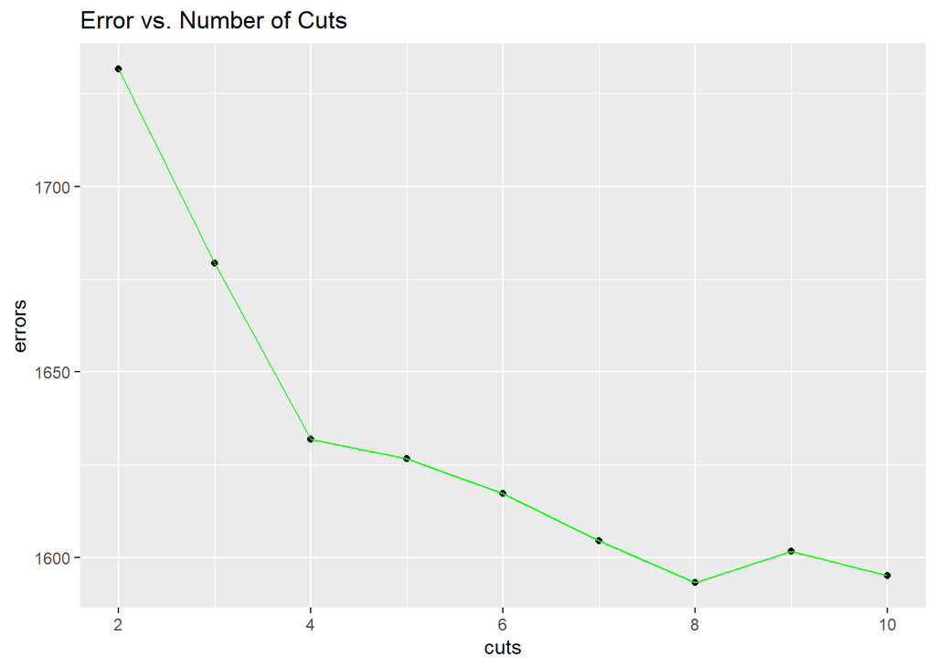

```r
tibble(cuts = 2:10, mse = errors) %>%
  ggplot(aes(x = cuts, y = errors))+
  geom_point()+
  geom_line(col = "green") +
  labs(title= "Error vs. Number of Cuts")
```

## 7.

This question just asks to try more models on wage. Checking means by factor, I see that education most strongly relates to earnings, as well as health insurance, race, and marital status. I worry about multicollinearity, however. I check some conditional means:

```r
library(ISLR)
glimpse(wage)
```

```
## Rows: 3,000
## Columns: 11
## $ year       <int> 2006, 2004, 2003, 2003, 2005, 2008, 2009, 2008, 2006, 20...
## $ age        <int> 18, 24, 45, 43, 50, 54, 44, 30, 41, 52, 45, 34, 35, 39, ...
## $ maritl     <fct> 1. Never Married, 1. Never Married, 2. Married, 2. Marri...
## $ race       <fct> 1. White, 1. White, 1. White, 3. Asian, 1. White, 1. Whi...
## $ education  <fct> 1. < HS Grad, 4. College Grad, 3. Some College, 4. Colle...
## $ region     <fct> 2. Middle Atlantic, 2. Middle Atlantic, 2. Middle Atlant...
## $ jobclass   <fct> 1. Industrial, 2. Information, 1. Industrial, 2. Informa...
## $ health     <fct> 1. <=Good, 2. >=Very Good, 1. <=Good, 2. >=Very Good, 1....
## $ health_ins <fct> 2. No, 2. No, 1. Yes, 1. Yes, 1. Yes, 1. Yes, 1. Yes, 1....
## $ logwage    <dbl> 4.318063, 4.255273, 4.875061, 5.041393, 4.318063, 4.8450...
## $ wage       <dbl> 75.04315, 70.47602, 130.98218, 154.68529, 75.04315, 127....
```

```r
map_if(wage, .p = is.factor, ~tapply(wage$wage, .x, mean, na.rm = TRUE), .else = as.null) %>%
  discard(is.null)
```

```
## $maritl
## 1. Never Married       2. Married       3. Widowed      4. Divorced
##         92.73465        118.86026         99.53866        103.15926
##     5. Separated
##        101.21579
##
## $race
##  1. White  2. Black  3. Asian  4. Other
## 112.56367 101.60118 120.28829  89.97333
##
## $education
##       1. < HS Grad         2. HS Grad    3. Some College    4. College Grad
##           84.10441           95.78335          107.75557          124.42791
## 5. Advanced Degree
##          150.91778
##
## $region
##        1. New England    2. Middle Atlantic 3. East North Central
##                    NA              111.7036                    NA
## 4. West North Central     5. South Atlantic 6. East South Central
##                    NA                    NA                    NA
## 7. West South Central           8. Mountain            9. Pacific
##                    NA                    NA                    NA
##
## $jobclass
##  1. Industrial 2. Information
##       103.3211       120.5927
##
## $health
##      1. <=Good 2. >=Very Good
##       101.6613       115.7262
##
## $health_ins
##   1. Yes    2. No
## 120.2383  92.3167
```

```r
tapply(wage$wage[wage$education == "1. < HS Grad"], wage$race[wage$education == "1. < HS Grad"], mean, na.rm = TRUE)
```

```
## 1. White 2. Black 3. Asian 4. Other
## 84.43814 86.83023 75.13738 82.24899
```

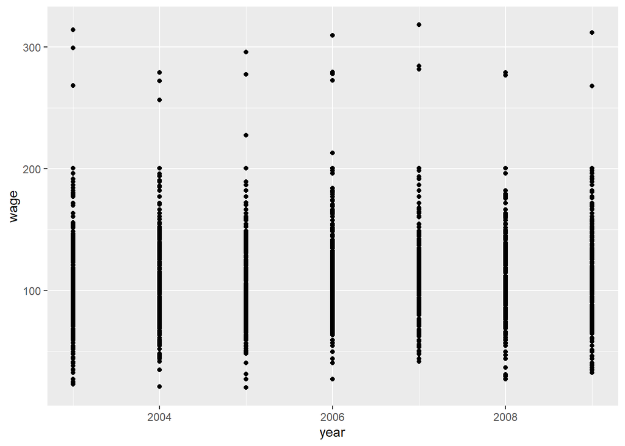

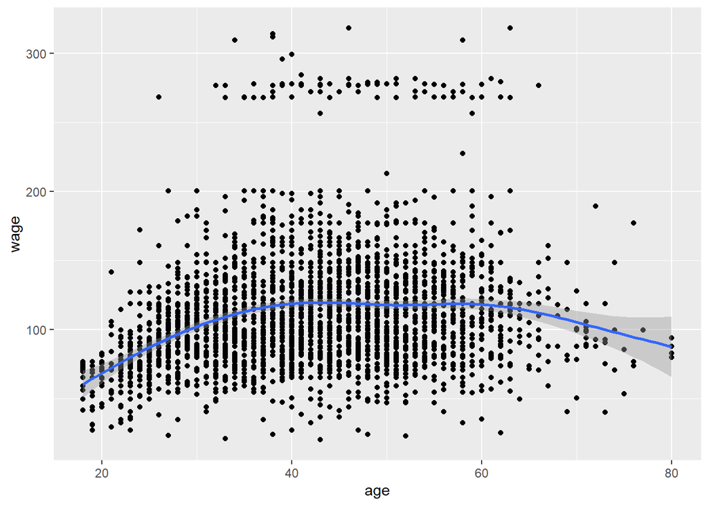

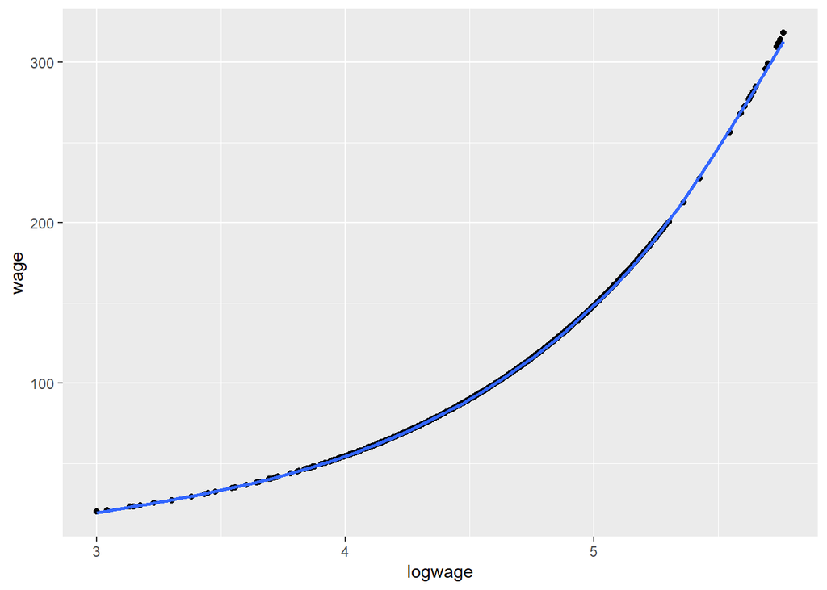

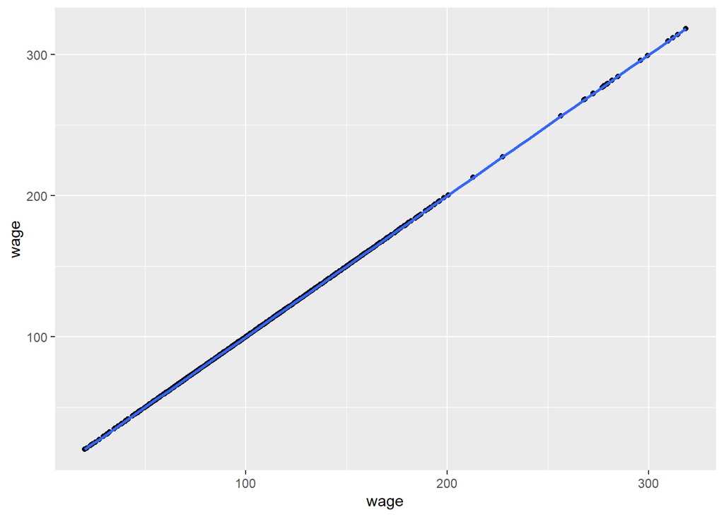

```r
imap(wage %>% dplyr::select(where(is.numeric)), ~ggplot(data = wage, aes(x = !!sym(.y), y = wage)) +
  geom_point() +
  geom_smooth())
```

```r
#Use tapply on subsets of a dataset defined by another factor.
tapply2 <- function(df, fac1, fac2, num, fun = mean, ...){

  #Caputr args in list
  args <- ensyms(fac1, fac2, num) %>% set_names(nm = c("fac1", "fac2", "num"))

  #Set caller environemnt to evaluate
  #envi <- parent.frame()
  subsets <- split(df, eval(expr(`$`(df, !!args$fac2))))

  #Map over susbets to compute susbet means
  out <- map(subsets, ~tapply(X = eval(expr(`$`(.x, !!args$num))),
                            INDEX = eval(expr(`$`(.x,!!args$fac1))), FUN = fun))
  out
}
```

Using my custom function, we see that income disparities holding constant education vary by race

```r
tapply2(wage, race, education, wage)
```

```
## $`1. < HS Grad`
## 1. White 2. Black 3. Asian 4. Other
## 84.43814 86.83023 75.13738 82.24899
##
## $`2. HS Grad`
## 1. White 2. Black 3. Asian 4. Other
## 96.69075 93.64141 85.11625 81.14495
##
## $`3. Some College`
## 1. White 2. Black 3. Asian 4. Other
## 109.0074 101.3955 100.1412 114.7850
##
## $`4. College Grad`
## 1. White 2. Black 3. Asian 4. Other
## 125.3255 111.7669 126.3294  79.0726
##
## $`5. Advanced Degree`
## 1. White 2. Black 3. Asian 4. Other
## 152.4550 137.8401 149.1472 106.9458
```

##8. We are asked to try some regression on the Auto dataset

```r
library(ISLR)
auto <- Auto

map(auto, summary)
```

```
## $mpg
##    Min. 1st Qu.  Median    Mean 3rd Qu.    Max.
##    9.00   17.00   22.75   23.45   29.00   46.60
##
## $cylinders
##    Min. 1st Qu.  Median    Mean 3rd Qu.    Max.
##   3.000   4.000   4.000   5.472   8.000   8.000
##
## $displacement
##    Min. 1st Qu.  Median    Mean 3rd Qu.    Max.
##    68.0   105.0   151.0   194.4   275.8   455.0
##
## $horsepower
##    Min. 1st Qu.  Median    Mean 3rd Qu.    Max.
##    46.0    75.0    93.5   104.5   126.0   230.0
##
## $weight
##    Min. 1st Qu.  Median    Mean 3rd Qu.    Max.
##    1613    2225    2804    2978    3615    5140
##
## $acceleration
##    Min. 1st Qu.  Median    Mean 3rd Qu.    Max.
##    8.00   13.78   15.50   15.54   17.02   24.80
##
## $year
##    Min. 1st Qu.  Median    Mean 3rd Qu.    Max.
##   70.00   73.00   76.00   75.98   79.00   82.00
##
## $origin
##    Min. 1st Qu.  Median    Mean 3rd Qu.    Max.
##   1.000   1.000   1.000   1.577   2.000   3.000
##
## $name
##                       amc matador                        ford pinto
##                                 5                                 5
##                    toyota corolla                       amc gremlin
##                                 5                                 4
##                        amc hornet                chevrolet chevette
##                                 4                                 4
##                  chevrolet impala                     ford maverick
```

[output cut: 78 more lines]

```
##                                 1                                 1
##                          capri ii         chevroelt chevelle malibu
##                                 1                                 1
##                 chevrolet bel air                  chevrolet camaro
##                                 1                                 1
##                chevrolet cavalier         chevrolet cavalier 2-door
##                                 1                                 1
##          chevrolet cavalier wagon  chevrolet chevelle concours (sw)
##                                 1                                 1
##                chevrolet concours     chevrolet malibu classic (sw)
##                                 1                                 1
##             chevrolet monte carlo           chevrolet monte carlo s
##                                 1                                 1
##               chevrolet monza 2+2                           (Other)
##                                 1                               202
```

```r
cor(auto[,-9])
```

```
##                     mpg  cylinders displacement horsepower     weight
## mpg           1.0000000 -0.7776175   -0.8051269 -0.7784268 -0.8322442
## cylinders    -0.7776175  1.0000000    0.9508233  0.8429834  0.8975273
## displacement -0.8051269  0.9508233    1.0000000  0.8972570  0.9329944
## horsepower   -0.7784268  0.8429834    0.8972570  1.0000000  0.8645377
## weight       -0.8322442  0.8975273    0.9329944  0.8645377  1.0000000
## acceleration  0.4233285 -0.5046834   -0.5438005 -0.6891955 -0.4168392
## year          0.5805410 -0.3456474   -0.3698552 -0.4163615 -0.3091199
## origin        0.5652088 -0.5689316   -0.6145351 -0.4551715 -0.5850054
##              acceleration       year     origin
## mpg             0.4233285  0.5805410  0.5652088
## cylinders      -0.5046834 -0.3456474 -0.5689316
## displacement   -0.5438005 -0.3698552 -0.6145351
## horsepower     -0.6891955 -0.4163615 -0.4551715
## weight         -0.4168392 -0.3091199 -0.5850054
## acceleration    1.0000000  0.2903161  0.2127458
## year            0.2903161  1.0000000  0.1815277
## origin          0.2127458  0.1815277  1.0000000
```

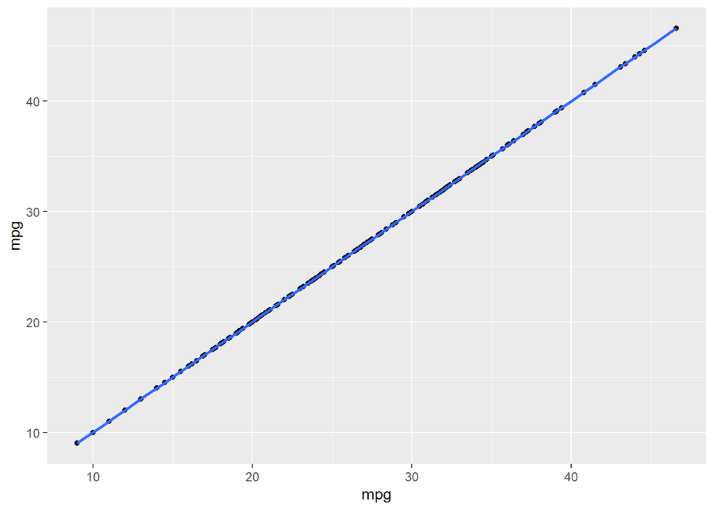

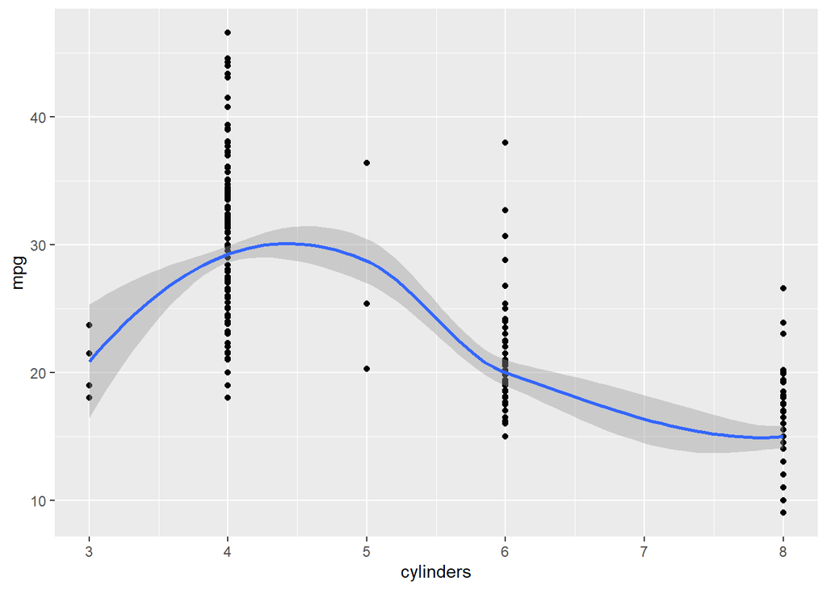

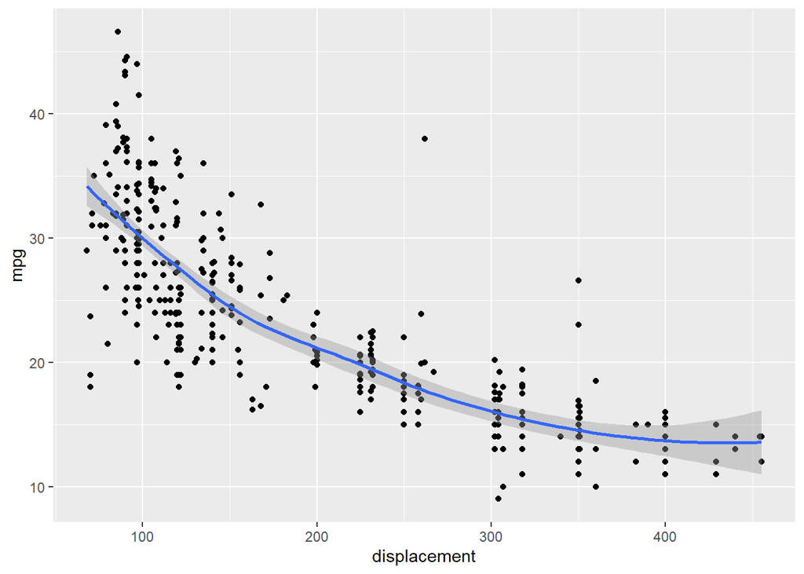

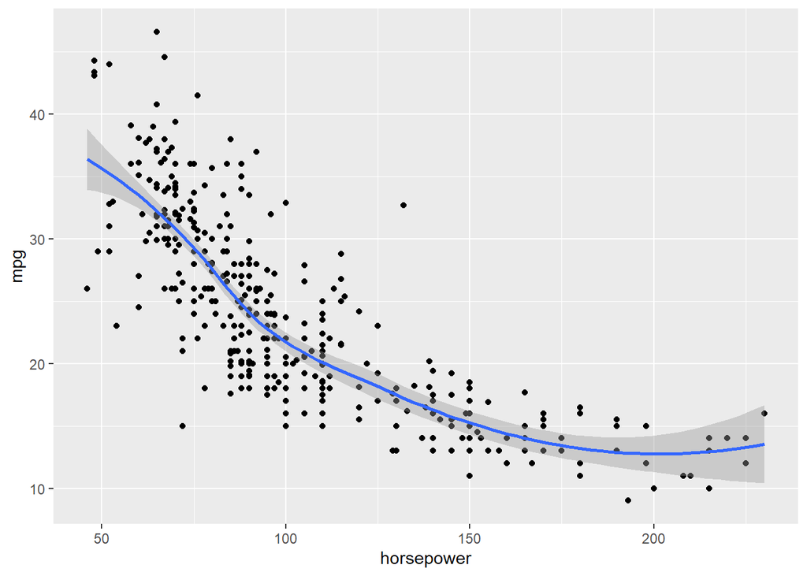

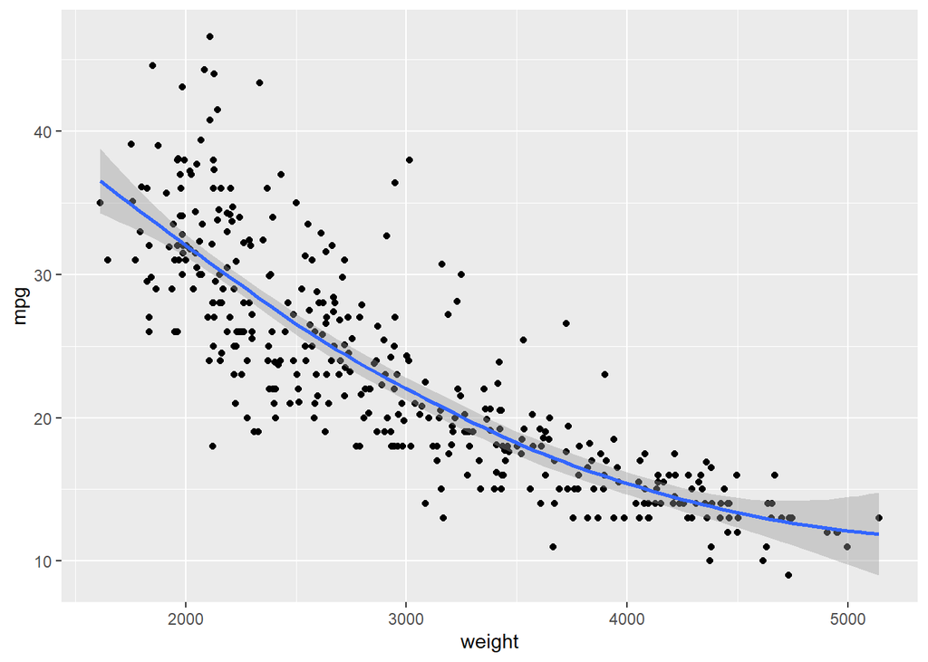

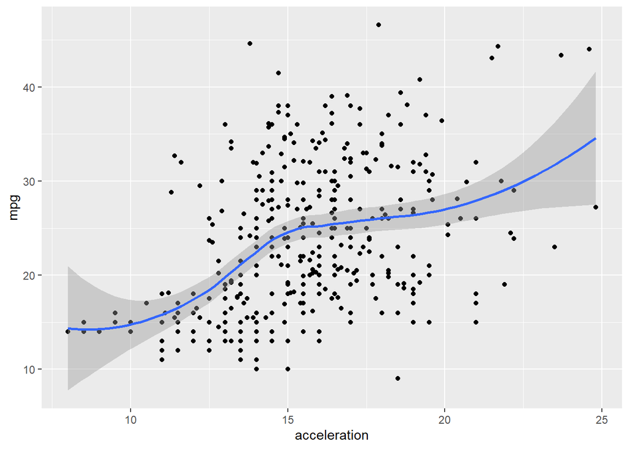

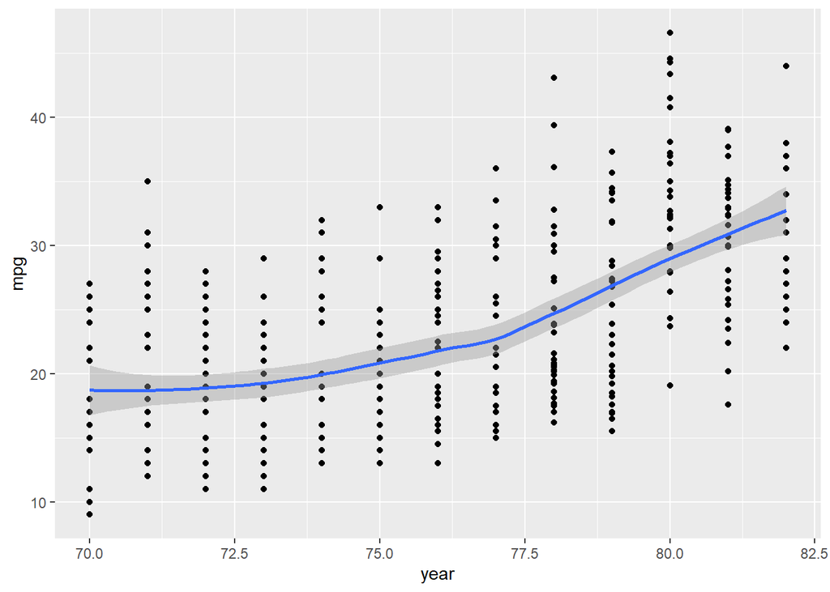

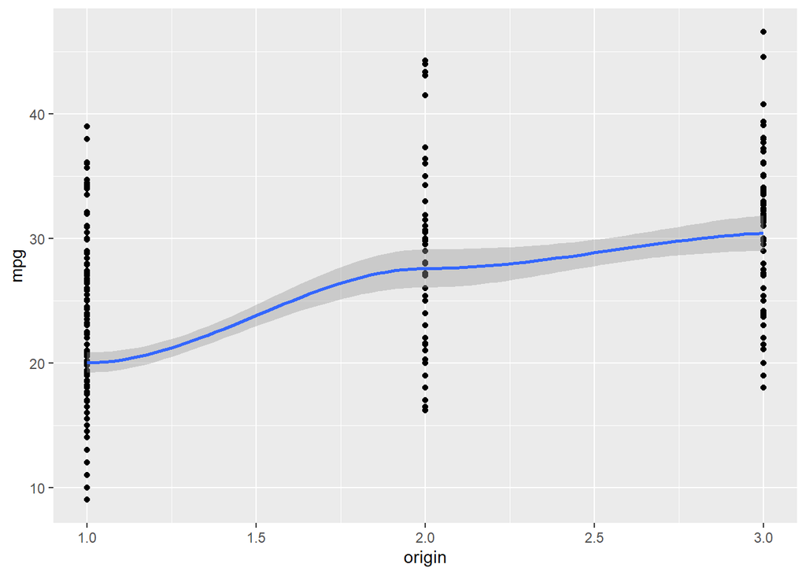

```r
auto %>% dplyr::select(-name) %>%
  imap(~ggplot(data = auto, aes(x= !!sym(.y), y = mpg))+
         geom_point() +
         geom_smooth())
```

```r
library(splines)

wage$educ2 <- fct_collapse(wage$education, subcollege = levels(wage$education)[1:3], college = levels(wage$education)[4:5])
mod1 <- lm(data = wage, wage ~  bs(age, degree = 3) + maritl + education + race + jobclass +health_ins)
```

## 9.

```r
library(ISLR)
# boston <- read_csv("C:/Users/heslinr1/Documents/Software/R/Projects/Exercises/data/housing.csv", col_names = FALSE) %>%
#   map(str_split, "\\s") %>%
#   map_depth(2, ~discard(.x, ~.x =="")) %>%
#   map_depth(2, ~set_names(.x, nm = c("crim", "zn", "indus", "chas", "nox", "rm", "age", "dis", "rad", "tax", "ptration", "b_1k", "lstat", "medv"))) %>%
#   bind_rows() %>%
#   mutate(across(everything(), as.numeric))

boston <- MASS::Boston

mod1 <- lm(nox ~poly(dis, 3), data = boston)
broom::glance(mod1)
```

```
## # A tibble: 1 x 12
##   r.squared adj.r.squared  sigma statistic   p.value    df logLik    AIC    BIC
##       <dbl>         <dbl>  <dbl>     <dbl>     <dbl> <dbl>  <dbl>  <dbl>  <dbl>
## 1     0.715         0.713 0.0621      419. 2.71e-136     3   690. -1371. -1350.
## # ... with 3 more variables: deviance <dbl>, df.residual <int>, nobs <int>
```

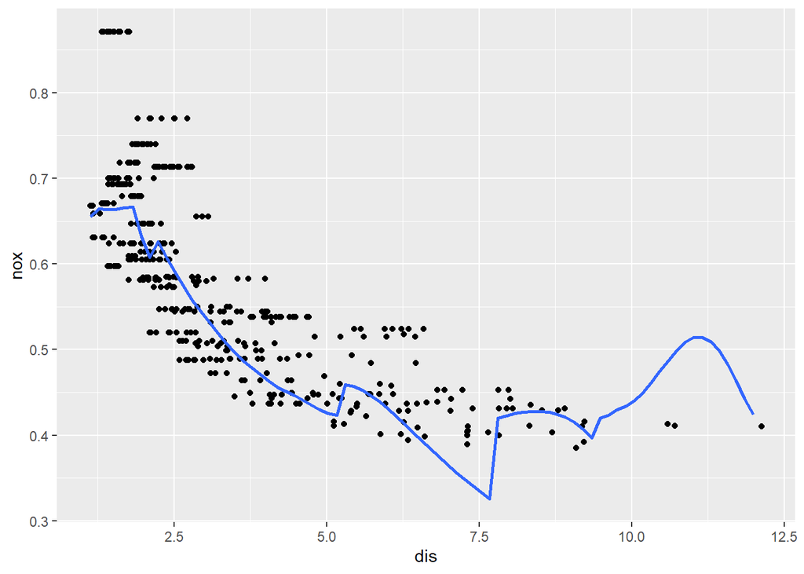

```r
#Sneaky function to sub in generic terms from a linear formula. Double substitute trick from Advanced R
sub_form <- function(form){

  pred <- all.vars(form)[2]
  resp <- all.vars(form)[1]


  #This works becuase the outer substitute quotes the inner one and substitutes form for temp. Evaluating the otuer substitute then subs in the correct value.
  envi <- list2(!!pred := sym("x"), !!resp := sym("y"))
  out <- eval(substitute(substitute(temp, envi), list(temp = form)))
  out
}
boston %>% ggplot(aes(x = dis,y = nox)) +
  geom_point() +
  geom_smooth(formula = sub_form(formula(mod1)), se = FALSE, span = 1)
```

I compare some polynomial fits of differing degree. The higher degrees are noticeably more variant near the ends of the domain.

```r
forms <- vector("list")
for(i in 1:10){

  #exp <- expr(wage~poly(age, i))
  #forms[[i]] <- eval(exp, e)
  forms[[i]] <- expr(nox ~ poly(dis, degree = !!i))

}
map(forms, lm, data = boston)  %>%
  map(broom::augment) %>%
map_dbl(~sum((.x$nox - .x$.fitted)^2))
```

```
##  [1] 2.768563 2.035262 1.934107 1.932981 1.915290 1.878257 1.849484 1.835630
##  [9] 1.833331 1.832171
```

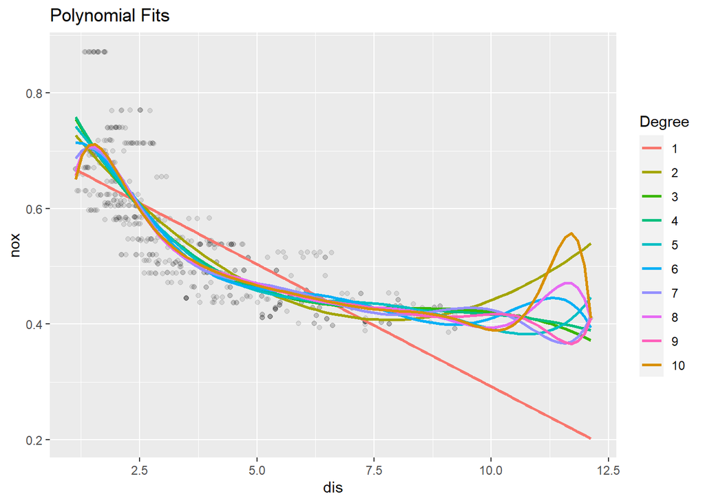

```r
generic <- map(forms, sub_form)

boston %>% ggplot(aes(x = dis, y = nox))+
  geom_jitter(alpha = .1)+
  imap(as.character(generic), ~geom_smooth(aes(col = as.character(.y)), formula = .x, se = FALSE, method = "lm")) +
  scale_color_discrete(name = "Degree", breaks = as.character(1:10)) +
  labs(title = "Polynomial Fits")
```

```r
folds <- make_folds(boston, 10)
```

```
## [1] "Generated 10 folds, including 6 of length 11"
```